# Blog corpus classification

Problem Statement: Build a NLP classifier which can use input text parameters to determine the label(s) of the blogs in a blog corpus.

This is the first notebook of the Blog corpus classification where TF-IDF vectorizer is used for fitting the models. In the second notebook, glove embeddings are used for fitting the models.

# Download Links

- dataset_path files: [Download Link](https://icedrive.net/0/1dVthqaAHs)
  1. corpus_docs_processed.pkl
  2. blogtext.csv
- Glove Embeddings: [Download Link](https://www.kaggle.com/thanakomsn/glove6b300dtxt)
- Training_Info files: [Download Link](https://icedrive.net/0/3eUpPdEcAZ)
  1. M1_finalmodel.h5
  2. M1_hist.npy
  3. M2_finalmodel.h5
  4. M2_hist.npy
  5. grids_tfidf_logreg_200K.joblib
  6. clf_tfidf_logreg_670K.pkl
  7. glove_emb_vars.npz
  8. clf_glove_logreg_670K.pkl

# Connect to Google Drive

```python
### Use this for Google Colab

from google.colab import drive
drive.mount('/content/drive')
```

# Import required libraries

```python
import numpy as np
import pandas as pd
import matplotlib as mpl
import matplotlib.pyplot as plt
import seaborn as sns
import datetime
import pytz
import pickle
import os
import math
sns.set(color_codes = True)
%matplotlib inline

import nltk
import re
from nltk.corpus import stopwords
from nltk.stem import PorterStemmer
from nltk.tokenize import RegexpTokenizer

from sklearn.feature_extraction.text import CountVectorizer
from sklearn.feature_extraction.text import TfidfVectorizer

from sklearn.linear_model import LogisticRegression
from sklearn.svm import SVC
from sklearn.ensemble import RandomForestClassifier
from sklearn.multioutput import MultiOutputClassifier
from sklearn.pipeline import make_pipeline
from sklearn.pipeline import Pipeline

from sklearn.model_selection import train_test_split
from sklearn.model_selection import ShuffleSplit
from sklearn.model_selection import cross_val_score
from sklearn.model_selection import cross_validate
from sklearn.model_selection import GridSearchCV
from sklearn.model_selection import RandomizedSearchCV
from sklearn.preprocessing import label_binarize

import tensorflow as tf
from tensorflow import keras
from tensorflow.keras import layers
from tensorflow.keras import regularizers
from tensorflow.keras import models
from tensorflow.keras import Model
from tensorflow.keras import optimizers
from tensorflow.keras import losses
from tensorflow.keras import metrics

from tensorflow.keras.models import Sequential
from tensorflow.keras.layers import Input, Flatten, Dense, Activation, Dropout
from tensorflow.keras.utils import to_categorical

from joblib import dump, load

from tqdm import tqdm
```

```python
# Set some plotting and printing ptions
mpl.rc('axes', labelsize = 30)
mpl.rc('axes', titlesize = 30)
mpl.rc('xtick', labelsize = 20)
mpl.rc('ytick', labelsize = 20)
mpl.rc('legend', fontsize = 20)
mpl.rc('figure', titlesize = 40)

pd.set_option('precision', 4) # Print 4 decimal places for all output parameters
```

# Set required directory paths

```python
### Use this for Google Colab

# Define base path for storing all outputs related to model / training
out_base_path = "/content/drive/MyDrive/AI_ML_Folder/Colab_Directory/Model_Outputs_New/NLP_Project_1_Part_I/Training_Info/"

# Define base path of dataset
dataset_path = "/content/drive/MyDrive/AI_ML_Folder/Colab_Directory/Model_Outputs_New/NLP_Project_1_Part_I/Datasets/"
```

# Import dataset

## Read input data as a dataframe

```python
#nrowsread = 100000
#df_orig = pd.read_csv('blogtext.csv', nrows = nrowsread)
df_orig = pd.read_csv(os.path.join(dataset_path, 'blogtext.csv'))
df_orig.rename(columns = {'topic': 'industry', 'sign': 'astro_sign'}, inplace = True)
df_orig.sample(5)
```

|  | id | gender | age | industry | astro_sign | date | text |
| --- | --- | --- | --- | --- | --- | --- | --- |
| 35151 | 3169212 | female | 15 | Student | Cancer | 01,August,2004 | CAPTAIN Jack Sparrow: You do have so... |
| 554212 | 3413263 | male | 25 | indUnk | Libra | 14,April,2004 | Greetings. I'm looking for someone to t... |
| 237682 | 449628 | male | 34 | indUnk | Aries | 22,July,2003 | 'I think that people are standing ... |
| 25160 | 3423174 | male | 14 | Internet | Gemini | 23,May,2004 | I'm losing all my free time, since my G... |
| 580055 | 3440978 | male | 24 | Education | Aries | 24,May,2004 | urlLink Did you hear about this? ... |

```python
# Drop date column as it will not be used in future processing
df_orig.drop(columns = 'date', inplace = True)
df_orig.sample(5)
```

|  | id | gender | age | industry | astro_sign | text |
| --- | --- | --- | --- | --- | --- | --- |
| 647245 | 2946219 | male | 27 | indUnk | Sagittarius | It's a wet and rainy Wednesday - pr... |
| 610744 | 1107146 | female | 16 | Student | Libra | Haha, its the day of really s... |
| 64603 | 4022877 | male | 37 | indUnk | Capricorn | urlLink Hans Zeiger's column today o... |
| 34160 | 3677506 | male | 25 | Technology | Libra | yes my friends, i'm doing well. contra... |
| 371070 | 2780794 | male | 17 | Student | Scorpio | Public Apology To SP Floorball Manageme... |

## Data types of each attribute

```python
# Print the data types of all columns
df_orig.dtypes
```

```
id             int64
gender        object
age            int64
industry      object
astro_sign    object
text          object
dtype: object
```

**'id' and 'age' are of numeric type. All other variables are categorical variables. 'id', however identifies a blogger and hence should be treated as a categorical variable.**

## Checking the presence of missing values

```python
df_orig.isna().sum()
```

```
id            0
gender        0
age           0
industry      0
astro_sign    0
text          0
dtype: int64
```

**There are no missing values in any of the columns.**

# Perform EDA on dataset

## Shape of dataset

```python
print("Number of blogs in dataset is %d" %(df_orig.shape[0]))
print("Number of columns in dataset is %d" %(df_orig.shape[1]))
```

```
Number of blogs in dataset is 681284
Number of columns in dataset is 6
```

## Get some information about bloggers

```
Number of unique bloggers is 19320
Number of unique male bloggers is 9660
Number of unique female bloggers is 9660
```

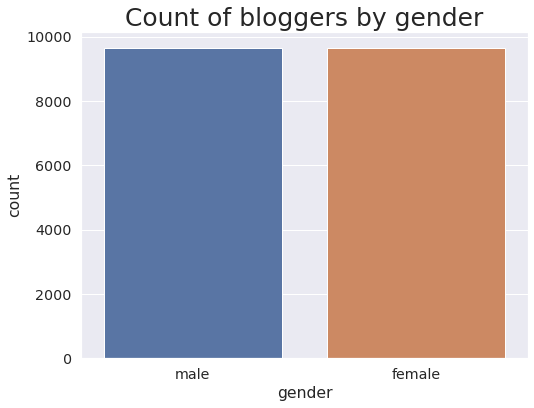

```python
# Number of unique bloggers
num_uniq_blog = len(df_orig['id'].unique())
# Number of female bloggers
num_fem_blog = df_orig.groupby(['id']).first()['gender'].value_counts().loc['female']
# Number of male bloggers
num_male_blog = df_orig.groupby(['id']).first()['gender'].value_counts().loc['male']

print("Number of unique bloggers is %d" %(num_uniq_blog))
print("Number of unique male bloggers is %d" %(num_male_blog))
print("Number of unique female bloggers is %d" %(num_fem_blog))
print()
print()
plt.figure(figsize = (8, 6))
sns.set(font_scale = 1.3)
sns.countplot(x = df_orig.groupby(['id']).first()['gender'])
plt.title("Count of bloggers by gender", fontsize = 25)
plt.show()
```

## Count of blogs by gender

```
Number of blogs written by male bloggers is 345193
Number of blogs written by female bloggers is 336091
```

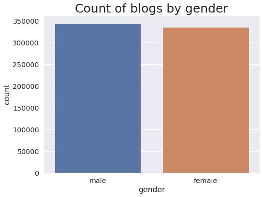

```python
num_blogs_by_male = df_orig['gender'].value_counts().loc['male']
num_blogs_by_female = df_orig['gender'].value_counts().loc['female']
print("Number of blogs written by male bloggers is %d" %(num_blogs_by_male))
print("Number of blogs written by female bloggers is %d" %(num_blogs_by_female))
print()
print()
plt.figure(figsize = (8, 6))
sns.set(font_scale = 1.3)
sns.countplot(x = df_orig['gender'])
plt.title("Count of blogs by gender", fontsize = 25)
plt.show()
```

## Count of blogs by age

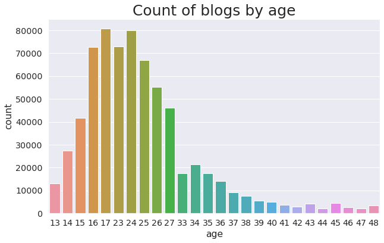

```python
plt.figure(figsize = (10, 6))
sns.set(font_scale = 1.3)
sns.countplot(x = df_orig['age'])
plt.title("Count of blogs by age", fontsize = 25)
plt.show()
```

**There are bloggers in three age groups - (13 - 17), (23 - 27), (33 - 48). Lets replace the age column with the following categories:**

- Age_10s (13 - 17)
- Age_20s (23 - 27)
- Age_30s (33 - 48)

```python
age_repl_dict = {13:'Age_10s', 14:'Age_10s', 15:'Age_10s', 16:'Age_10s', 17:'Age_10s',
                 23:'Age_20s', 24:'Age_20s', 25:'Age_20s', 26:'Age_20s', 27:'Age_20s',
                 33:'Age_30s', 34:'Age_30s', 35:'Age_30s', 36:'Age_30s', 37:'Age_30s',
                 38:'Age_30s', 39:'Age_30s', 40:'Age_30s', 41:'Age_30s', 42:'Age_30s',
                 43:'Age_30s', 44:'Age_30s', 45:'Age_30s', 46:'Age_30s', 47:'Age_30s',
                 48:'Age_30s'
                }
df_orig['age'].replace(to_replace = age_repl_dict, inplace = True)
df_orig['age'].unique()
```

```
array(['Age_10s', 'Age_30s', 'Age_20s'], dtype=object)
```

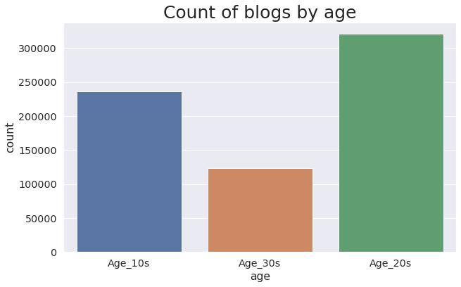

```python
plt.figure(figsize = (10, 6))
sns.set(font_scale = 1.3)
sns.countplot(x = df_orig['age'])
plt.title("Count of blogs by age", fontsize = 25)
plt.show()
```

## Count of blogs by astrological sign

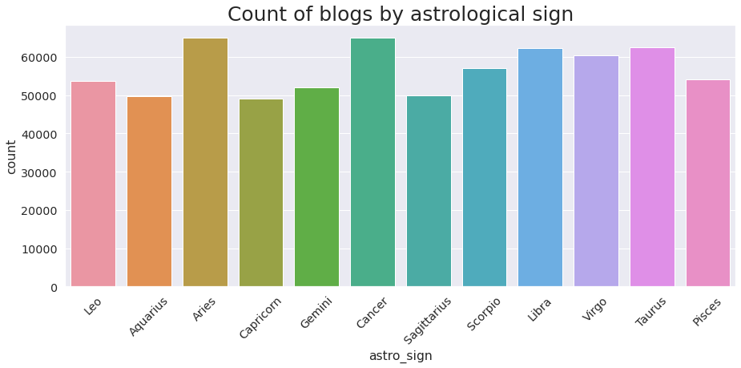

```python
plt.figure(figsize = (15, 6))
sns.set(font_scale = 1.3)
sns.countplot(x = df_orig['astro_sign'])
plt.title("Count of blogs by astrological sign", fontsize = 25)
plt.xticks(rotation = 45)
plt.show()
```

## Count of blogs by industry

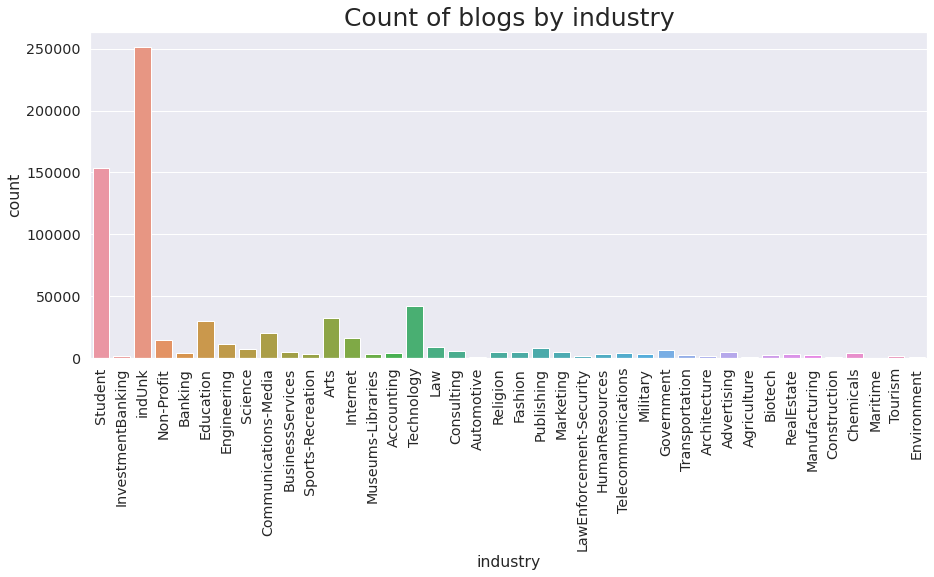

```python
plt.figure(figsize = (15, 6))
sns.set(font_scale = 1.3)
sns.countplot(x = df_orig['industry'])
plt.title("Count of blogs by industry", fontsize = 25)
plt.xticks(rotation = 90)
plt.show()
```

**As seen above, "IndustryUnknown" and "Student" categories account for most of the blogs and the remaining categories are very less in number each. It will be difficult for any learning algorithm to classify these categories because of the small number of samples available. Lets merge all these other categories into a single category - "Ind_Other".**

```python
ind_repl_list = ['InvestmentBanking', 'Non-Profit', 'Banking',\
                 'Education', 'Engineering', 'Science', 'Communications-Media',\
                 'BusinessServices', 'Sports-Recreation', 'Arts', 'Internet',\
                 'Museums-Libraries', 'Accounting', 'Technology', 'Law',\
                 'Consulting', 'Automotive', 'Religion', 'Fashion', 'Publishing',\
                 'Marketing', 'LawEnforcement-Security', 'HumanResources',\
                 'Telecommunications', 'Military', 'Government', 'Transportation',\
                 'Architecture', 'Advertising', 'Agriculture', 'Biotech',\
                 'RealEstate', 'Manufacturing', 'Construction', 'Chemicals',\
                 'Maritime', 'Tourism', 'Environment']
df_orig['industry'].replace(to_replace = ind_repl_list, value = 'Ind_Other', inplace = True)
df_orig['industry'].unique()
```

```
array(['Student', 'Ind_Other', 'indUnk'], dtype=object)
```

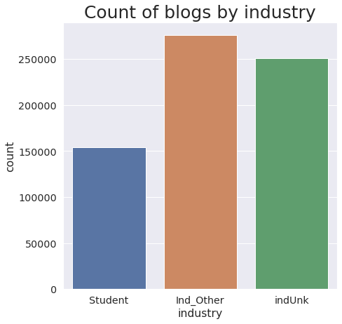

```python
plt.figure(figsize = (7, 7))
sns.set(font_scale = 1.3)
sns.countplot(x = df_orig['industry'])
plt.title("Count of blogs by industry", fontsize = 25)
#plt.xticks(rotation = 90)
plt.show()
```

```python
print("Number of individuals for whom industry is unknown is %d"\
      %(df_orig['industry'] == 'indUnk').sum())
```

```
Number of individuals for whom industry is unknown is 251015
```

# Define required functions

## Function: Get list of all characters in a corpus

```python
def get_char_list(corpus):

    '''
    Get a list of lexicographically sorted characters present in corpus

    Arguments:
        corpus - Input corpus from which list of characters has to be extracted.

    Returns:
        List of all characters in corpus sorted lexicographically.
    '''

    all_char_pattern = re.compile(r'.') # Match all characters in corpus except newline
    all_char_list = [] # Placeholder to store all characters in corpus

    for doc in tqdm(corpus): # Loop through all documents in corpus and extract all characters
        doc = doc.lower() # Convert document to lower-case
        matches = all_char_pattern.finditer(doc)
        for mat in matches:
            all_char_list.append(mat.group(0)) # Append characters from current document

    # Get unique characters, convert to list and sort.
    uniq_char_list = sorted(list(set(all_char_list)))

    print()
    print("Number of unique characters is %d" %len(uniq_char_list))
    print()
    # print("List of unique characters:")
    # print("==========================")
    # print("{}".format(uniq_char_list))

    return uniq_char_list
```

## Function: Get list of all words in a corpus

```python
def get_words_list(corpus):

    '''
    Get a list of all words in the corpus sorted lexicographically.

    Arguments:
        corpus - Input corpus from which list of words has to be extracted.

    Returns:
        List of all words in corpus sorted lexicographically.
    '''

    all_words_list = [] # Placeholder to store all words in corpus

    for doc in tqdm(corpus): # Loop through all documents in corpus and extract all words
        doc = doc.lower() # Convert document to lower-case
        wordlist = doc.split(" ")
        all_words_list.extend(wordlist)

    uniq_words_list = sorted(list(set(all_words_list)))

    print()
    print("Number of unique words is %d" %len(uniq_words_list))
    print()
    # print("First 20 unique words:")
    # print("======================")
    # print("{}".format(uniq_words_list[:20]))
    # print()
    # print("Last 20 unique words:")
    # print("=====================")
    # print("{}".format(uniq_words_list[-20:]))

    return uniq_words_list
```

## Function: Pre-process features

```python
def preprocess_feat(corpus, stopword_list, stemmer):

    '''
    Pre-process each document in corpus. Includes the following:
        1. Convert to lower-case
        2. Remove html tags
        3. Delete single-quote characters (don't will become dont)
        3. Replace miscellaneous characters with whitespace
        4. Split document into words, perform stemming and merge stemmed words back into document

    Arguments:
        corpus - Input corpus.
        stemmer - Stemmer object to use for performing stemming

    Returns:
        Pre-processed corpus.
    '''

    corpus_docs_processed = [] # Placeholder to store processed documents from corpus
    for doc in tqdm(corpus): # Loop through all documents in corpus
        # Convert document to all lower-case
        doc_proc = doc.lower()

        # Search for html tags in the current document (if any) and replace them with space
        html_tag_patt = re.compile('<.*?>')
        doc_proc = re.sub(html_tag_patt, ' ', doc_proc)

        # Search for quote character (if any) and delete it
        # This will make words like don't = dont and won't = wont
        pattern_1 = re.compile(r'[\']')
        doc_proc = re.sub(pattern_1, '', doc_proc)

        # Search for miscellaneous characters (if any) and replace them with whitespace
        # Standard symbols in QWErtY keyboard to be replaced with whitespace
        pattern_2 = re.compile(r'[`|~|!|@|#|$|%|^|&|*|(|)|\-|_|=|+|\[|\]|{|}|\|;|:|"|,|.|/|<|>|?]')
        doc_proc = re.sub(pattern_2, ' ', doc_proc)

        # Split document into list of words, remove stopwords and perform stemming on each word
        words = [stemmer.stem(word) for word in doc_proc.split() if word not in stopword_list]
        # Concatenate words back into a document
        doc_proc = ''
        for word in words:
            doc_proc = doc_proc + word + ' '

        # Append current processed document to corpus_docs_processed
        corpus_docs_processed.append(doc_proc)

    return corpus_docs_processed
```

## Function: Get results from fitted classifier

```python
def get_results(pipe, X_train, X_test, y_train, y_test):

    '''
    Function to extract results from fitted classifier pipe

    Arguments:
        pipe - Fitted classifier pipe
        X_train: Training set corpus docs
        X_test: Test set corpus docs
        y_train: Training set corpus labels
        y_test: Test set corpus labels

    '''

    vect_fit = pipe.named_steps['vect'] # Extracted fitted vectorizer from pipe
    feat_names = vect_fit.get_feature_names() # Extract vocab from tfidf vectorizer
    print("Number of extracted features: {}".format(len(feat_names)))
    print()

    # Convert X_train and X_test into tf-idf vectors
    X_train_tfidf = vect_fit.transform(X_train)
    X_test_tfidf = vect_fit.transform(X_test)

    # Extract individual classifiers for gender, age, industry and astrosign
    clf_gender = pipe.named_steps['clf'].estimators_[0]
    clf_age = pipe.named_steps['clf'].estimators_[1]
    clf_industry = pipe.named_steps['clf'].estimators_[2]
    clf_astrosign = pipe.named_steps['clf'].estimators_[3]

    # Evaluate overall training and test set scores
    score_overall_train = pipe.score(X_train, y_train)
    score_overall_test = pipe.score(X_test, y_test)

    # Evaluate each individual classifier on X_train_tfidf and X_test_tfidf
    score_gender_train = clf_gender.score(X_train_tfidf, y_train[:, 0])
    score_gender_test = clf_gender.score(X_test_tfidf, y_test[:, 0])
    score_age_train = clf_age.score(X_train_tfidf, y_train[:, 1])
    score_age_test = clf_age.score(X_test_tfidf, y_test[:, 1])
    score_industry_train = clf_industry.score(X_train_tfidf, y_train[:, 2])
    score_industry_test = clf_industry.score(X_test_tfidf, y_test[:, 2])
    score_astrosign_train = clf_astrosign.score(X_train_tfidf, y_train[:, 3])
    score_astrosign_test = clf_astrosign.score(X_test_tfidf, y_test[:, 3])

    print("Training set: Overall score: %0.2f %%" %(100 * score_overall_train))
    print("Training set: Gender score: %0.2f %%" %(100 * score_gender_train))
    print("Training set: Age score: %0.2f %%" %(100 * score_age_train))
    print("Training set: Industry score: %0.2f %%" %(100 * score_industry_train))
    print("Training set: Astrosign score: %0.2f %%" %(100 * score_astrosign_train))
    print()
    print("Test set: Overall score: %0.2f %%" %(100 * score_overall_test))
    print("Test set: Gender score: %0.2f %%" %(100 * score_gender_test))
    print("Test set: Age score: %0.2f %%" %(100 * score_age_test))
    print("Test set: Industry score: %0.2f %%" %(100 * score_industry_test))
    print("Test set: Astrosign score: %0.2f %%" %(100 * score_astrosign_test))
```

# Create corpus and labels

```python
corpus_docs = df_orig['text'] # Create corpus with all text documents extracted from dataframe
```

## Obtain count of unique characters and unique words in original corpus

```python
### This section is commented out as it take a long time to run

# uniq_char_list = get_char_list(corpus_docs)
# uniq_words_list = get_words_list(corpus_docs)
```

## Pre-process corpus

In this step, the documents in the corpus are pre-processed with the following steps:

- All documents converted to lower-case.
- HTML tags (if any) are removed.
- Single-quote characters (if any) are removed.
- Multiple miscellaneous characters are replaced with whitespace.
- Stopwords (from English) are removed.
- Porter stemmer is used to perform stemming on the words.

Since this step takes a long time to run, it is performed once and the processed corpus is stored to disk.

```python
### This section is commented out.

# # Stemming and stopword removal is done only for English words
# stemmer = PorterStemmer() # Instantiate Porter Stemmer
# stopword_list = stopwords.words('english') # List of stopwords to remove

# # Pre-process corpus documents
# corpus_docs_processed = preprocess_feat(corpus_docs, stopword_list, stemmer)
```

### Save pre-processed corpus to disk

```python
### This section is commented out.

# file_name = "./corpus_docs_processed.pkl"
# with open(file_name, "wb") as file:
#     pickle.dump(corpus_docs_processed, file)
```

### Load pre-processed corpus from disk

```python
file_name = os.path.join(dataset_path, "corpus_docs_processed.pkl")
with open(file_name, "rb") as file:
    corpus_docs_processed = pickle.load(file)
print("Loaded pre-processed corpus from disk...")
```

```
Loaded pre-processed corpus from disk...
```

### Obtain count of unique characters and unique words in pre-processed corpus

```python
### This section is commented out as it take a long time to run

# uniq_char_list = get_char_list(corpus_docs_processed)
# uniq_words_list = get_words_list(corpus_docs_processed)
```

**The number of unique characters in the corpus was found to be 7489 and the number of unique words is 644825.**

## Generate labels

We will set this up as a multi-label multi-class classification problem. The output labels will be 'gender', 'age', 'industry' and 'astro-sign'.

```python
y = np.array(df_orig[['gender', 'age', 'industry', 'astro_sign']])
print("Number of unique values of gender is %d" % (np.unique(y[:, 0]).shape[0]))
print("Number of unique values of age is %d" % (np.unique(y[:, 1]).shape[0]))
print("Number of unique values of industry is %d" % (np.unique(y[:, 2]).shape[0]))
print("Number of unique values of astro_sign is %d" % (np.unique(y[:, 3]).shape[0]))
```

```
Number of unique values of gender is 2
Number of unique values of age is 3
Number of unique values of industry is 3
Number of unique values of astro_sign is 12
```

**The above results show the number of unique classes in each output label.**

## Generate train / test splits

Since we have a large training corpus available, the following strategy will be used for obtaining train / val / test splits.

- The dataset will first be split into a training set and a test set with a fixed test-set size of 10000 documents.
- While performing cross-validation, a separate validation set (of size 10000) will be created using 'shufflesplit'

```python
# First split corpus into train and test datasets.
# Test set size is set to 10000 samples
X_train_orig, X_test, y_train_orig, y_test = train_test_split(corpus_docs_processed, y,\
                                                    test_size = 10000, random_state = 0)
print("X_train_orig.shape: {}" .format(len(X_train_orig)))
print("y_train_orig.shape: {}" .format(y_train_orig.shape))
print("X_test.shape: {}" .format(len(X_test)))
print("y_test.shape: {}" .format(y_test.shape))
print()
print("Number of unique values of gender in y_train_orig is %d"\
      % (np.unique(y_train_orig[:, 0]).shape[0]))
print("Number of unique values of age in y_train_orig is %d"\
      % (np.unique(y_train_orig[:, 1]).shape[0]))
print("Number of unique values of industry in y_train_orig is %d"\
      % (np.unique(y_train_orig[:, 2]).shape[0]))
print("Number of unique values of astro_sign in y_train_orig is %d"\
      % (np.unique(y_train_orig[:, 3]).shape[0]))
```

```
X_train_orig.shape: 671284
y_train_orig.shape: (671284, 4)
X_test.shape: 10000
y_test.shape: (10000, 4)

Number of unique values of gender in y_train_orig is 2
Number of unique values of age in y_train_orig is 3
Number of unique values of industry in y_train_orig is 3
Number of unique values of astro_sign in y_train_orig is 12
```

```python
# Delete unnecessary variables to save memory

del y, corpus_docs_processed,df_orig, corpus_docs
```

## Reduce training set size for hyperparameter tuning

Since the training set is too large, we will create a smaller subset of the training set for hyperparameter tuning.

```python
# ### This section is commented out as these commands are re-used below

# num_train_samples = 210000 # Number of samples to use for the training set
# X_train = X_train_orig[:num_train_samples]
# y_train = y_train_orig[:num_train_samples]

# print("X_train.shape: {}" .format(len(X_train)))
# print("y_train.shape: {}" .format(y_train.shape))
```

# Model - Define, tune, fit and evaluate

We will evaluate two types of classifiers:

- **Supervised learning classifier:** Since we have a large training set and also a large number of features, we will choose the logistic regression classifier for this task.
- **Neural-Network based classifier:** We will then repeat the same classification exercise using a fully-connected neural network to build the classifier.

The results of the hyperparameter tuning will be stored to disk and retrieved from disk for subsequent runs.

# Supervised-Learning based model

```python
### Hyperparameter tuning - Final grid search object will be saved to disk.

# Vectorization of the corpus documents will be done using TF-IDF
# Hyperparameters:
#    ngram_range: Either (1, 1) or (1, 2)
#    max_features: 10000 / 25000 / 50000
vect = TfidfVectorizer(ngram_range = (1, 1), max_features = 10000)

# The logistic regression classifier can output only a single label.
# The MultiOutputClassifier wrapper will be used to build a multi-label classifier.
# Hyperparameters:
#    C: (0.1 to 1000) in logarithmic scale
clf = MultiOutputClassifier(LogisticRegression(), n_jobs = -1)

# Define classifier pipeline - (Vectorizer followed by classifier)
pipe = Pipeline([("vect",vect), ("clf", clf)])

# Define parameter grid for grid search
param_grid = {"vect__max_features": [10000, 20000, 50000],
              "vect__ngram_range": [(1, 1), (1, 2)],
              "clf__estimator__C": [0.1, 1, 10, 100, 1000]
             }

# Define shuffle splitter to generate validation set.
ss = ShuffleSplit(n_splits = 1, test_size = 10000, random_state = 0)
# Define grid search object
grids = GridSearchCV(pipe, param_grid, cv = ss, verbose = 3, return_train_score = True, refit = True)

# Start timer
start_time = datetime.datetime.now(pytz.timezone('Asia/Kolkata'))
print("Started grid search at %s" %(start_time.strftime("%H:%M:%S")), end = '; ')

### Since the grid search takes long time to run, this line is commented out.
### The results of the grid search have been stored to disk and will be read
### back from disk in the next section

# # Run grid search
# grids.fit(X_train, y_train)

# End timer
end_time = datetime.datetime.now(pytz.timezone('Asia/Kolkata'))
elap_time = ((end_time - start_time).total_seconds())/60
print("Completed at %s. Elapsed time = %0.2f minutes." %(end_time.strftime("%H:%M:%S"), elap_time))
print()

# # Save grid search object to file
# fname = os.path.join(out_base_path, "grids_200K.joblib") # Name of file to store search results
# dump(grids, fname)
```

```
Started grid search at 13:07:32; Completed at 13:07:32. Elapsed time = 0.00 minutes.
```

## Results summary

```python
# Define file to load search results from
fname = os.path.join(out_base_path, "grids_tfidf_logreg_200K.joblib")
grids = load(fname) # Load search object from joblib file

# Extract best estimator from grid search object
pipe_best = grids.best_estimator_

print("Best validation set score is %0.2f %%" % (100 * grids.best_score_))
print("Best parameters obtained from grid search are:\n{}" .format(grids.best_params_))
print()

# Recreate training set
num_train_samples = 210000 # Number of samples to use for the training set
X_train = X_train_orig[:num_train_samples]
y_train = y_train_orig[:num_train_samples]

# The following script will report the following.
# Number of extracted features in the best classifier
# Since this is a multi-output classifier, this script will extract the training set and test
# set accuracies for each output and report them along with the overall training set and test
# set scores
get_results(pipe_best, X_train, X_test, y_train, y_test)
```

```
Best validation set score is 8.95 %
Best parameters obtained from grid search are:
{'clf__estimator__C': 10, 'vect__max_features': 50000, 'vect__ngram_range': (1, 1)}

Number of extracted features: 50000

Training set: Overall score: 15.77 %
Training set: Gender score: 76.48 %
Training set: Age score: 71.82 %
Training set: Industry score: 58.27 %
Training set: Astrosign score: 34.49 %

Test set: Overall score: 8.22 %
Test set: Gender score: 69.78 %
Test set: Age score: 67.40 %
Test set: Industry score: 48.76 %
Test set: Astrosign score: 20.04 %
```

**The best estimator has the following parameters:**

- TF-IDF - ngram_range: (1, 1)
- TF-IDF - max_features: (50000)
- LogisticRegression - Regularization parameter (C): 10

From the above results, we can see that the classifier achieves a test set accuracy of around 70% on gender and 67% on age but performs poorly on industry and very poorly on astrosign. This is most likely because the blogs are not as representative of the industry and astrosign of the bloggers as they are of the age and gender of the bloggers. Lets now use the best parameters obtained above and re-fit the classifier with the entire training set.

```python
# Delete unnecessary variables to save memory

del pipe_best
del X_train
del y_train
```

```python
num_train_samples = 670000 # Number of samples to use for the training set
X_train = X_train_orig[:num_train_samples]
y_train = y_train_orig[:num_train_samples]

print("X_train.shape: {}" .format(len(X_train)))
print("y_train.shape: {}" .format(y_train.shape))
print()

### This section is commented out. The fitted model will be loaded from disk in the next section.

# # Re-fit classifier with best parameters
# vect_best = TfidfVectorizer(ngram_range = (1, 1), max_features = 50000)
# clf_best = MultiOutputClassifier(LogisticRegression(C = 10), n_jobs = -1)
# pipe_best = Pipeline([("vect",vect_best), ("clf", clf_best)])

# # Start timer
# start_time = datetime.datetime.now(pytz.timezone('Asia/Kolkata'))
# print("Started classifier fit at %s" %(start_time.strftime("%H:%M:%S")), end = '; ')

# # Fit classifier
# pipe_best.fit(X_train, y_train)

# # End timer
# end_time = datetime.datetime.now(pytz.timezone('Asia/Kolkata'))
# elap_time = ((end_time - start_time).total_seconds())/60
# print("Completed at %s. Elapsed time = %0.2f minutes." %(end_time.strftime("%H:%M:%S"), elap_time))
# print()

# # Store fitted classifier to disk
# file_name = os.path.join(out_base_path, "clf_tfidf_logreg_670K.pkl")
# with open(file_name, "wb") as file:
#     pickle.dump(pipe_best, file)
```

```
X_train.shape: 670000
y_train.shape: (670000, 4)
```

```python
# Read fitted classifier from disk
file_name = os.path.join(out_base_path, "clf_tfidf_logreg_670K.pkl")
with open(file_name, "rb") as file:
    pipe_best = pickle.load(file)

# # The following script will report the following.
# # Number of extracted features in the best classifier
# # Since this is a multi-output classifier, this script will extract the training set and test
# # set accuracies for each output and report them along with the overall training set and test
# # set scores
get_results(pipe_best, X_train, X_test, y_train, y_test)
```

```
Number of extracted features: 50000

Training set: Overall score: 12.21 %
Training set: Gender score: 73.75 %
Training set: Age score: 68.98 %
Training set: Industry score: 54.65 %
Training set: Astrosign score: 27.49 %

Test set: Overall score: 9.37 %
Test set: Gender score: 71.28 %
Test set: Age score: 68.57 %
Test set: Industry score: 52.07 %
Test set: Astrosign score: 21.70 %
```

**Increasing the training set size didn't significantly change the test set accuracies. Results are almost similar to the previous case.**

Next, we will be build a fully-connected NN based model.</b>

```python
# Delete unnecessary variables to save memory

del pipe_best
del X_train
del y_train
```

# Neural-Network based model

## Function: Define a Batch Generator

```python
def batch_generator(X, y_gen, y_age, y_ind, y_sgn, batch_size = 200):

    '''
    Batch generator to convert input from sparse array to dense numpy array.

    '''

    while (True):

        # Generate indices for current batch and create current batch X and y
        indices = np.random.randint(0, X.shape[0], size = batch_size).tolist()
        batch_X = X[indices].toarray() # Convert sparse array to dense numpy array
        batch_y_gen = y_gen[indices]
        batch_y_age = y_age[indices]
        batch_y_ind = y_ind[indices]
        batch_y_sgn = y_sgn[indices]

        # Return batch - use yield function to make it a python generator
        yield batch_X, [batch_y_gen, batch_y_age, batch_y_ind, batch_y_sgn]
```

## Prepare input and labels for NN model

```python
num_train_samples = 110000 # Number of samples to use for the training set
X_train = X_train_orig[:num_train_samples]
y_train = y_train_orig[:num_train_samples]

max_features = 50000 # Maximum features to generate from TF-IDF vectorizer

# Define TF-IDF vectorizer
vect_NN = TfidfVectorizer(ngram_range = (1, 1), max_features = max_features)

# Obtain sparse-vectorized version of corpus features
X_train_NN_full = vect_NN.fit_transform(X_train)
X_test_NN = vect_NN.transform(X_test)

# Generate train / val split from X_train_NN_full
# Val set size = 10000
ss = ShuffleSplit(n_splits = 1, test_size = 10000, random_state = 0)
train_index, val_index = next(ss.split(X_train_NN_full))
X_train_NN = X_train_NN_full[train_index] # Training set features
X_val_NN = X_train_NN_full[val_index] # Validation set features

# Obtain list of unique values of gender, age, industry and astro-sign
gen_uniq_list = list(np.unique(y_train[:, 0]))
age_uniq_list = list(np.unique(y_train[:, 1]))
ind_uniq_list = list(np.unique(y_train[:, 2]))
sgn_uniq_list = list(np.unique(y_train[:, 3]))

# Create dictionary mapping from index to value of the above unique lists
# This will be used while making predictions using the NN model.
gen_dict = {ind:val for ind, val in enumerate(gen_uniq_list)}
age_dict = {ind:val for ind, val in enumerate(age_uniq_list)}
ind_dict = {ind:val for ind, val in enumerate(ind_uniq_list)}
sgn_dict = {ind:val for ind, val in enumerate(sgn_uniq_list)}

# Generate train / val labels with One-Hot-Encoding for gender, age, industry and astro-sign
y_train_gen_NN = label_binarize(y_train[train_index, 0], classes = gen_uniq_list)
y_val_gen_NN = label_binarize(y_train[val_index, 0], classes = gen_uniq_list)
y_test_gen_NN = label_binarize(y_test[:, 0], classes = gen_uniq_list)

y_train_age_NN = label_binarize(y_train[train_index, 1], classes = age_uniq_list)
y_val_age_NN = label_binarize(y_train[val_index, 1], classes = age_uniq_list)
y_test_age_NN = label_binarize(y_test[:, 1], classes = age_uniq_list)

y_train_ind_NN = label_binarize(y_train[train_index, 2], classes = ind_uniq_list)
y_val_ind_NN = label_binarize(y_train[val_index, 2], classes = ind_uniq_list)
y_test_ind_NN = label_binarize(y_test[:, 2], classes = ind_uniq_list)

y_train_sgn_NN = label_binarize(y_train[train_index, 3], classes = sgn_uniq_list)
y_val_sgn_NN = label_binarize(y_train[val_index, 3], classes = sgn_uniq_list)
y_test_sgn_NN = label_binarize(y_test[:, 3], classes = sgn_uniq_list)

print("Shape of X_train_NN is: {}" .format(X_train_NN.shape))
print("Shape of X_val_NN is: {}" .format(X_val_NN.shape))
print("Shape of X_test_NN is: {}" .format(X_test_NN.shape))
print()
print("Shape of y_train_gen_NN is: {}" .format(y_train_gen_NN.shape))
print("Shape of y_val_gen_NN is: {}" .format(y_val_gen_NN.shape))
print("Shape of y_test_gen_NN is: {}" .format(y_test_gen_NN.shape))
print()
print("Shape of y_train_age_NN is: {}" .format(y_train_age_NN.shape))
print("Shape of y_val_age_NN is: {}" .format(y_val_age_NN.shape))
print("Shape of y_test_age_NN is: {}" .format(y_test_age_NN.shape))
print()
print("Shape of y_train_ind_NN is: {}" .format(y_train_ind_NN.shape))
print("Shape of y_val_ind_NN is: {}" .format(y_val_ind_NN.shape))
print("Shape of y_test_ind_NN is: {}" .format(y_test_ind_NN.shape))
print()
print("Shape of y_train_sgn_NN is: {}" .format(y_train_sgn_NN.shape))
print("Shape of y_val_sgn_NN is: {}" .format(y_val_sgn_NN.shape))
print("Shape of y_test_sgn_NN is: {}" .format(y_test_sgn_NN.shape))
```

```
Shape of X_train_NN is: (100000, 50000)
Shape of X_val_NN is: (10000, 50000)
Shape of X_test_NN is: (10000, 50000)

Shape of y_train_gen_NN is: (100000, 1)
Shape of y_val_gen_NN is: (10000, 1)
Shape of y_test_gen_NN is: (10000, 1)

Shape of y_train_age_NN is: (100000, 3)
Shape of y_val_age_NN is: (10000, 3)
Shape of y_test_age_NN is: (10000, 3)

Shape of y_train_ind_NN is: (100000, 3)
Shape of y_val_ind_NN is: (10000, 3)
Shape of y_test_ind_NN is: (10000, 3)

Shape of y_train_sgn_NN is: (100000, 12)
Shape of y_val_sgn_NN is: (10000, 12)
Shape of y_test_sgn_NN is: (10000, 12)
```

## Define batch generators

```python
batch_size = 1000
train_gen = batch_generator(X_train_NN, y_train_gen_NN, y_train_age_NN, y_train_ind_NN,\
                            y_train_sgn_NN, batch_size = batch_size)
val_gen = batch_generator(X_val_NN, y_val_gen_NN, y_val_age_NN,  y_val_ind_NN,\
                          y_val_sgn_NN, batch_size = batch_size)
test_gen = batch_generator(X_test_NN, y_test_gen_NN, y_test_age_NN,  y_test_ind_NN,\
                          y_test_sgn_NN, batch_size = batch_size)

# Define steps per epoch for train, val and test sets
train_steps_per_epoch = math.ceil(X_train_NN.shape[0] / batch_size)
val_steps_per_epoch = math.ceil(X_val_NN.shape[0] / batch_size)
test_steps_per_epoch = math.ceil(X_test_NN.shape[0] / batch_size)
```

## Define model

```python
# Common section for all outputs
# Inputs -> Dense(128, ReLU) -> Dropout(0.5) -> Dense(128, ReLU) -> Dropout(0.5) -> X
inputs = Input(shape = (max_features,))
X = Dense(128, activation = 'relu')(inputs)
X = Dropout(0.5)(X)
X = Dense(128, activation = 'relu')(X)
X = Dropout(0.5)(X)

# Branch for gender output
# X -> Dense(128, ReLU) -> Dropout(0.5) ->  Dense(64, ReLU) -> Dropout(0.5) ->
# -> Dense(64, ReLU) -> Dropout(0.5) -> Dense(1, sigmoid) -> gen_output
X_gen = Dense(128, activation = 'relu')(X)
X_gen = Dropout(0.5)(X_gen)
X_gen = Dense(64, activation = 'relu')(X_gen)
X_gen = Dropout(0.5)(X_gen)
X_gen = Dense(64, activation = 'relu')(X_gen)
X_gen = Dropout(0.5)(X_gen)
gen_output = Dense(1, activation = 'sigmoid', name = 'gen_op')(X_gen) # Gender label output

# Branch for age output
# X -> Dense(128, ReLU) -> Dropout(0.5) ->  Dense(64, ReLU) -> Dropout(0.5) ->
# -> Dense(64, ReLU) -> Dropout(0.5) -> Dense(3, softmax) -> age_output
X_age = Dense(128, activation = 'relu')(X)
X_age = Dropout(0.5)(X_age)
X_age = Dense(64, activation = 'relu')(X_age)
X_age = Dropout(0.5)(X_age)
X_age = Dense(64, activation = 'relu')(X_age)
X_age = Dropout(0.5)(X_age)
age_output = Dense(3, activation = 'softmax', name = 'age_op')(X_age) # Age label output

# Branch for industry output
# X -> Dense(128, ReLU) -> Dropout(0.5) ->  Dense(64, ReLU) -> Dropout(0.5) ->
# -> Dense(64, ReLU) -> Dropout(0.5) -> Dense(3, softmax) -> ind_output
X_ind = Dense(128, activation = 'relu')(X)
X_ind = Dropout(0.5)(X_ind)
X_ind = Dense(64, activation = 'relu')(X_ind)
X_ind = Dropout(0.5)(X_ind)
X_ind = Dense(64, activation = 'relu')(X_ind)
X_ind = Dropout(0.5)(X_ind)
ind_output = Dense(3, activation = 'softmax', name = 'ind_op')(X_ind) # Industry label output

# Branch for astro-sign output
# X -> Dense(128, ReLU) -> Dropout(0.5) ->  Dense(64, ReLU) -> Dropout(0.5) ->
# -> Dense(64, ReLU) -> Dropout(0.5) -> Dense(12, softmax) -> sgn_output
X_sgn = Dense(128, activation = 'relu')(X)
X_sgn = Dropout(0.5)(X_sgn)
X_sgn = Dense(64, activation = 'relu')(X_sgn)
X_sgn = Dropout(0.5)(X_sgn)
X_sgn = Dense(64, activation = 'relu')(X_sgn)
X_sgn = Dropout(0.5)(X_sgn)
sgn_output = Dense(12, activation = 'softmax', name = 'sgn_op')(X_sgn) # Sign label output

# Define overall model with single input and four outputs
model = Model(inputs = inputs, outputs = [gen_output, age_output, ind_output, sgn_output])
model.summary()
```

```
Model: "model"
__________________________________________________________________________________________________
Layer (type)                    Output Shape         Param #     Connected to
==================================================================================================
input_1 (InputLayer)            [(None, 50000)]      0
__________________________________________________________________________________________________
dense (Dense)                   (None, 128)          6400128     input_1[0][0]
__________________________________________________________________________________________________
dropout (Dropout)               (None, 128)          0           dense[0][0]
__________________________________________________________________________________________________
dense_1 (Dense)                 (None, 128)          16512       dropout[0][0]
__________________________________________________________________________________________________
dropout_1 (Dropout)             (None, 128)          0           dense_1[0][0]
__________________________________________________________________________________________________
dense_2 (Dense)                 (None, 128)          16512       dropout_1[0][0]
__________________________________________________________________________________________________
dense_5 (Dense)                 (None, 128)          16512       dropout_1[0][0]
__________________________________________________________________________________________________
dense_8 (Dense)                 (None, 128)          16512       dropout_1[0][0]
__________________________________________________________________________________________________
dense_11 (Dense)                (None, 128)          16512       dropout_1[0][0]
__________________________________________________________________________________________________
dropout_2 (Dropout)             (None, 128)          0           dense_2[0][0]
__________________________________________________________________________________________________
dropout_5 (Dropout)             (None, 128)          0           dense_5[0][0]
__________________________________________________________________________________________________
dropout_8 (Dropout)             (None, 128)          0           dense_8[0][0]
__________________________________________________________________________________________________
dropout_11 (Dropout)            (None, 128)          0           dense_11[0][0]
__________________________________________________________________________________________________
dense_3 (Dense)                 (None, 64)           8256        dropout_2[0][0]
__________________________________________________________________________________________________
dense_6 (Dense)                 (None, 64)           8256        dropout_5[0][0]
__________________________________________________________________________________________________
dense_9 (Dense)                 (None, 64)           8256        dropout_8[0][0]
__________________________________________________________________________________________________
dense_12 (Dense)                (None, 64)           8256        dropout_11[0][0]
__________________________________________________________________________________________________
dropout_3 (Dropout)             (None, 64)           0           dense_3[0][0]
__________________________________________________________________________________________________
```

[output cut: 19 more lines]

```
__________________________________________________________________________________________________
dropout_13 (Dropout)            (None, 64)           0           dense_13[0][0]
__________________________________________________________________________________________________
gen_op (Dense)                  (None, 1)            65          dropout_4[0][0]
__________________________________________________________________________________________________
age_op (Dense)                  (None, 3)            195         dropout_7[0][0]
__________________________________________________________________________________________________
ind_op (Dense)                  (None, 3)            195         dropout_10[0][0]
__________________________________________________________________________________________________
sgn_op (Dense)                  (None, 12)           780         dropout_13[0][0]
==================================================================================================
Total params: 6,533,587
Trainable params: 6,533,587
Non-trainable params: 0
__________________________________________________________________________________________________
```

## Compile model

```python
# Define Optimizer - Adam with default settings
opt = optimizers.Adam()

# Define Loss - BCE for gender and CCE for age, industry and astrosign
bce = keras.losses.BinaryCrossentropy()
cce = keras.losses.CategoricalCrossentropy()
loss_dict = {'gen_op': bce, 'age_op': cce, 'ind_op': cce, 'sgn_op': cce}

# Define Metric - Binary accuracy for gender and categorical accuracy for age, industry and astrosign
gen_met = keras.metrics.BinaryAccuracy()
age_met = keras.metrics.CategoricalAccuracy()
ind_met = keras.metrics.CategoricalAccuracy()
sgn_met = keras.metrics.CategoricalAccuracy()
met_dict = {'gen_op': [gen_met], 'age_op': [age_met], 'ind_op': [ind_met],'sgn_op': [sgn_met]}

model.compile(optimizer = opt, loss = loss_dict, metrics = met_dict)
```

## Fit model

In the section below, the model 'fit' command is executed. Since this takes a long time to run, this section is commented out and the saved results will be loaded back from disk.

```python
### This section is commented out

# # Prefix to use for naming files and paths
# mod_file_pref = "MB"
# # Path for storing final trained model
# fm_path = os.path.join(out_base_path, mod_file_pref + "_finalmodel.h5")
# # Path for storing training history
# hi_path = os.path.join(out_base_path, mod_file_pref + "_hist.npy")

# # Fit model
# hist = model.fit(x = train_gen, epochs = 200, steps_per_epoch = train_steps_per_epoch, verbose = 1,\
#                  validation_data = val_gen, validation_steps = val_steps_per_epoch)

# # Save model and history files to disk
# model.save(fm_path, overwrite = True, save_format = 'h5')
# np.save(hi_path, hist.history)
```

```python
# Delete unnecessary variables to save memory

del X_train, X_train_NN_full, X_train_NN, X_val_NN, X_test_NN
del y_train
del y_train_gen_NN, y_val_gen_NN, y_test_gen_NN
del y_train_age_NN, y_val_age_NN, y_test_age_NN
del y_train_ind_NN, y_val_ind_NN, y_test_ind_NN
del y_train_sgn_NN, y_val_sgn_NN, y_test_sgn_NN
del model
```

## Results summary

### Model - M1

- Vectorizer = TF-IDF; ngram_range: (1, 2); max_features = 100K
- Training set size = 100K samples
- Trained for 200 epochs.

#### Define file paths

```python
### Define file paths
mod_file_pref = "M1"
fm_path = os.path.join(out_base_path, mod_file_pref + "_finalmodel.h5")
hi_path = os.path.join(out_base_path, mod_file_pref + "_hist.npy")

# Load model with final trained weights
model = models.load_model(fm_path)

# Print model summary
model.summary()
```

```
Model: "model_3"
__________________________________________________________________________________________________
Layer (type)                    Output Shape         Param #     Connected to
==================================================================================================
input_4 (InputLayer)            [(None, 100000)]     0
__________________________________________________________________________________________________
dense_42 (Dense)                (None, 128)          12800128    input_4[0][0]
__________________________________________________________________________________________________
dropout_42 (Dropout)            (None, 128)          0           dense_42[0][0]
__________________________________________________________________________________________________
dense_43 (Dense)                (None, 128)          16512       dropout_42[0][0]
__________________________________________________________________________________________________
dropout_43 (Dropout)            (None, 128)          0           dense_43[0][0]
__________________________________________________________________________________________________
dense_44 (Dense)                (None, 128)          16512       dropout_43[0][0]
__________________________________________________________________________________________________
dense_47 (Dense)                (None, 128)          16512       dropout_43[0][0]
__________________________________________________________________________________________________
dense_50 (Dense)                (None, 128)          16512       dropout_43[0][0]
__________________________________________________________________________________________________
dense_53 (Dense)                (None, 128)          16512       dropout_43[0][0]
__________________________________________________________________________________________________
dropout_44 (Dropout)            (None, 128)          0           dense_44[0][0]
__________________________________________________________________________________________________
dropout_47 (Dropout)            (None, 128)          0           dense_47[0][0]
__________________________________________________________________________________________________
dropout_50 (Dropout)            (None, 128)          0           dense_50[0][0]
__________________________________________________________________________________________________
dropout_53 (Dropout)            (None, 128)          0           dense_53[0][0]
__________________________________________________________________________________________________
dense_45 (Dense)                (None, 64)           8256        dropout_44[0][0]
__________________________________________________________________________________________________
dense_48 (Dense)                (None, 64)           8256        dropout_47[0][0]
__________________________________________________________________________________________________
dense_51 (Dense)                (None, 64)           8256        dropout_50[0][0]
__________________________________________________________________________________________________
dense_54 (Dense)                (None, 64)           8256        dropout_53[0][0]
__________________________________________________________________________________________________
dropout_45 (Dropout)            (None, 64)           0           dense_45[0][0]
__________________________________________________________________________________________________
```

[output cut: 19 more lines]

```
__________________________________________________________________________________________________
dropout_55 (Dropout)            (None, 64)           0           dense_55[0][0]
__________________________________________________________________________________________________
gen_op (Dense)                  (None, 1)            65          dropout_46[0][0]
__________________________________________________________________________________________________
age_op (Dense)                  (None, 3)            195         dropout_49[0][0]
__________________________________________________________________________________________________
ind_op (Dense)                  (None, 3)            195         dropout_52[0][0]
__________________________________________________________________________________________________
sgn_op (Dense)                  (None, 12)           780         dropout_55[0][0]
==================================================================================================
Total params: 12,933,587
Trainable params: 12,933,587
Non-trainable params: 0
__________________________________________________________________________________________________
```

#### Prepare input and labels for evaluation

```python
num_train_samples = 110000 # Number of samples to use for the training set
X_train = X_train_orig[:num_train_samples]
y_train = y_train_orig[:num_train_samples]

max_features = 100000 # Maximum features to generate from TF-IDF vectorizer

# Define TF-IDF vectorizer
vect_NN = TfidfVectorizer(ngram_range = (1, 2), max_features = max_features)
# Obtain sparse-vectorized version of corpus features
X_train_NN_full = vect_NN.fit_transform(X_train)
X_test_NN = vect_NN.transform(X_test)

# Generate train / val split from X_train_NN_full
# Val set size = 10000
ss = ShuffleSplit(n_splits = 1, test_size = 10000, random_state = 0)
train_index, val_index = next(ss.split(X_train_NN_full))
X_train_NN = X_train_NN_full[train_index] # Training set features
X_val_NN = X_train_NN_full[val_index] # Validation set features

# Generate train / val labels with One-Hot-Encoding for gender, age, industry and astro-sign
y_train_gen_NN = label_binarize(y_train[train_index, 0], classes = gen_uniq_list)
y_val_gen_NN = label_binarize(y_train[val_index, 0], classes = gen_uniq_list)
y_test_gen_NN = label_binarize(y_test[:, 0], classes = gen_uniq_list)

y_train_age_NN = label_binarize(y_train[train_index, 1], classes = age_uniq_list)
y_val_age_NN = label_binarize(y_train[val_index, 1], classes = age_uniq_list)
y_test_age_NN = label_binarize(y_test[:, 1], classes = age_uniq_list)

y_train_ind_NN = label_binarize(y_train[train_index, 2], classes = ind_uniq_list)
y_val_ind_NN = label_binarize(y_train[val_index, 2], classes = ind_uniq_list)
y_test_ind_NN = label_binarize(y_test[:, 2], classes = ind_uniq_list)

y_train_sgn_NN = label_binarize(y_train[train_index, 3], classes = sgn_uniq_list)
y_val_sgn_NN = label_binarize(y_train[val_index, 3], classes = sgn_uniq_list)
y_test_sgn_NN = label_binarize(y_test[:, 3], classes = sgn_uniq_list)

print("Shape of X_train_NN is: {}" .format(X_train_NN.shape))
print("Shape of X_val_NN is: {}" .format(X_val_NN.shape))
print("Shape of X_test_NN is: {}" .format(X_test_NN.shape))
print()
print("Shape of y_train_gen_NN is: {}" .format(y_train_gen_NN.shape))
print("Shape of y_val_gen_NN is: {}" .format(y_val_gen_NN.shape))
print("Shape of y_test_gen_NN is: {}" .format(y_test_gen_NN.shape))
print()
print("Shape of y_train_age_NN is: {}" .format(y_train_age_NN.shape))
print("Shape of y_val_age_NN is: {}" .format(y_val_age_NN.shape))
print("Shape of y_test_age_NN is: {}" .format(y_test_age_NN.shape))
print()
print("Shape of y_train_ind_NN is: {}" .format(y_train_ind_NN.shape))
print("Shape of y_val_ind_NN is: {}" .format(y_val_ind_NN.shape))
print("Shape of y_test_ind_NN is: {}" .format(y_test_ind_NN.shape))
print()
print("Shape of y_train_sgn_NN is: {}" .format(y_train_sgn_NN.shape))
print("Shape of y_val_sgn_NN is: {}" .format(y_val_sgn_NN.shape))
print("Shape of y_test_sgn_NN is: {}" .format(y_test_sgn_NN.shape))
```

```
Shape of X_train_NN is: (100000, 100000)
Shape of X_val_NN is: (10000, 100000)
Shape of X_test_NN is: (10000, 100000)

Shape of y_train_gen_NN is: (100000, 1)
Shape of y_val_gen_NN is: (10000, 1)
Shape of y_test_gen_NN is: (10000, 1)

Shape of y_train_age_NN is: (100000, 3)
Shape of y_val_age_NN is: (10000, 3)
Shape of y_test_age_NN is: (10000, 3)

Shape of y_train_ind_NN is: (100000, 3)
Shape of y_val_ind_NN is: (10000, 3)
Shape of y_test_ind_NN is: (10000, 3)

Shape of y_train_sgn_NN is: (100000, 12)
Shape of y_val_sgn_NN is: (10000, 12)
Shape of y_test_sgn_NN is: (10000, 12)
```

```python
# Define batch generators for above input
batch_size = 1000
train_gen = batch_generator(X_train_NN, y_train_gen_NN, y_train_age_NN, y_train_ind_NN,\
                            y_train_sgn_NN, batch_size = batch_size)
val_gen = batch_generator(X_val_NN, y_val_gen_NN, y_val_age_NN,  y_val_ind_NN,\
                          y_val_sgn_NN, batch_size = batch_size)
test_gen = batch_generator(X_test_NN, y_test_gen_NN, y_test_age_NN,  y_test_ind_NN,\
                          y_test_sgn_NN, batch_size = batch_size)

# Define steps per epoch for train, val and test sets
train_steps_per_epoch = math.ceil(X_train_NN.shape[0] / batch_size)
val_steps_per_epoch = math.ceil(X_val_NN.shape[0] / batch_size)
test_steps_per_epoch = math.ceil(X_test_NN.shape[0] / batch_size)
```

#### Plot learning curves

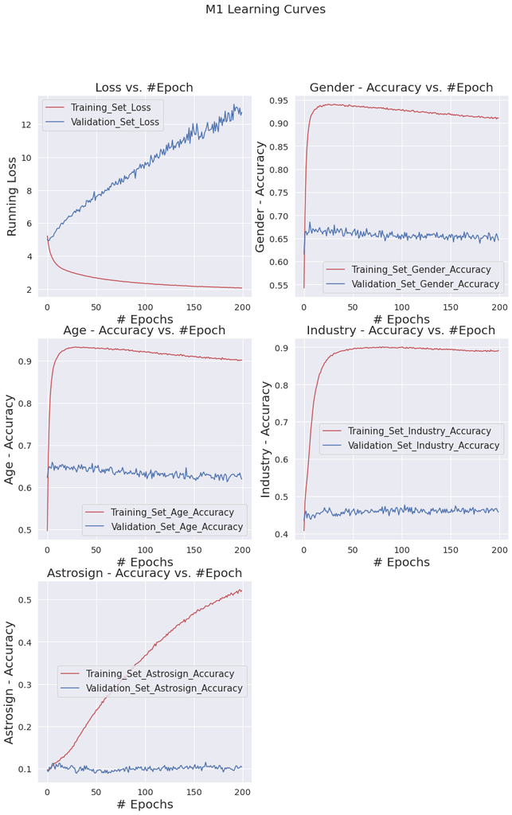

```python
# Load history files from disk
hist_model = np.load(hi_path, allow_pickle = 'TRUE').item()

# Plot training and validation loss
fig = plt.figure(figsize = (14, 21))
fig.suptitle(mod_file_pref + " Learning Curves", fontsize = 20)
ax1 = plt.subplot(3, 2, 1)
ax1.plot(hist_model['loss'], 'r-', label = 'Training_Set_Loss')
ax1.plot(hist_model['val_loss'], 'b-', label = 'Validation_Set_Loss')
ax1.set_title("Loss vs. #Epoch", fontsize = 20)
ax1.set_ylabel('Running Loss', fontsize = 20)
ax1.set_xlabel('# Epochs', fontsize = 20)
ax1.grid(b = True)
ax1.legend(fontsize = 15)

ax2 = plt.subplot(3, 2, 2)
ax2.plot(hist_model['gen_op_binary_accuracy'], 'r-', label = 'Training_Set_Gender_Accuracy')
ax2.plot(hist_model['val_gen_op_binary_accuracy'], 'b-', label = 'Validation_Set_Gender_Accuracy')
ax2.set_title("Gender - Accuracy vs. #Epoch", fontsize = 20)
ax2.set_ylabel('Gender - Accuracy', fontsize = 20)
ax2.set_xlabel('# Epochs', fontsize = 20)
ax2.grid(b = True)
ax2.legend(fontsize = 15)

ax3 = plt.subplot(3, 2, 3)
ax3.plot(hist_model['age_op_categorical_accuracy'], 'r-', label = 'Training_Set_Age_Accuracy')
ax3.plot(hist_model['val_age_op_categorical_accuracy'], 'b-', label = 'Validation_Set_Age_Accuracy')
ax3.set_title("Age - Accuracy vs. #Epoch", fontsize = 20)
ax3.set_ylabel('Age - Accuracy', fontsize = 20)
ax3.set_xlabel('# Epochs', fontsize = 20)
ax3.grid(b = True)
ax3.legend(fontsize = 15)

ax4 = plt.subplot(3, 2, 4)
ax4.plot(hist_model['ind_op_categorical_accuracy'], 'r-', label = 'Training_Set_Industry_Accuracy')
ax4.plot(hist_model['val_ind_op_categorical_accuracy'], 'b-', label = 'Validation_Set_Industry_Accuracy')
ax4.set_title("Industry - Accuracy vs. #Epoch", fontsize = 20)
ax4.set_ylabel('Industry - Accuracy', fontsize = 20)
ax4.set_xlabel('# Epochs', fontsize = 20)
ax4.grid(b = True)
ax4.legend(fontsize = 15)

ax5 = plt.subplot(3, 2, 5)
ax5.plot(hist_model['sgn_op_categorical_accuracy'], 'r-', label = 'Training_Set_Astrosign_Accuracy')
ax5.plot(hist_model['val_sgn_op_categorical_accuracy'], 'b-', label = 'Validation_Set_Astrosign_Accuracy')
ax5.set_title("Astrosign - Accuracy vs. #Epoch", fontsize = 20)
ax5.set_ylabel('Astrosign - Accuracy', fontsize = 20)
ax5.set_xlabel('# Epochs', fontsize = 20)
ax5.grid(b = True)
ax5.legend(fontsize = 15)

plt.show()
```

#### Evaluate accuracy on train and val sets

```python
# Evaluate model on training set
res = model.evaluate(x = train_gen, steps = train_steps_per_epoch, verbose = 0, return_dict = True)
print("Training set gender accuracy is %0.2f %%"\
      %(100 * res['gen_op_gen_op_binary_accuracy']))
print("Training set age accuracy is %0.2f %%"\
      %(100 * res['age_op_age_op_categorical_accuracy']))
print("Training set industry accuracy is %0.2f %%"\
      %(100 * res['ind_op_ind_op_categorical_accuracy']))
print("Training set astrosign accuracy is %0.2f %%"\
      %(100 * res['sgn_op_sgn_op_categorical_accuracy']))
print()

# Evaluate model on validation set
res = model.evaluate(x = val_gen, steps = val_steps_per_epoch, verbose = 0, return_dict = True)
print("Validation set gender accuracy is %0.2f %%"\
      %(100 * res['gen_op_gen_op_binary_accuracy']))
print("Validation set age accuracy is %0.2f %%"\
      %(100 * res['age_op_age_op_categorical_accuracy']))
print("Validation set industry accuracy is %0.2f %%"\
      %(100 * res['ind_op_ind_op_categorical_accuracy']))
print("Validation set astrosign accuracy is %0.2f %%"\
      %(100 * res['sgn_op_sgn_op_categorical_accuracy']))
print()

# Evaluate model on test set
res = model.evaluate(x = test_gen, steps = test_steps_per_epoch, verbose = 0, return_dict = True)
print("Test set gender accuracy is %0.2f %%"\
      %(100 * res['gen_op_gen_op_binary_accuracy']))
print("Test set age accuracy is %0.2f %%"\
      %(100 * res['age_op_age_op_categorical_accuracy']))
print("Test set industry accuracy is %0.2f %%"\
      %(100 * res['ind_op_ind_op_categorical_accuracy']))
print("Test set astrosign accuracy is %0.2f %%"\
      %(100 * res['sgn_op_sgn_op_categorical_accuracy']))
```

```
Training set gender accuracy is 96.73 %
Training set age accuracy is 97.14 %
Training set industry accuracy is 95.67 %
Training set astrosign accuracy is 55.26 %

Validation set gender accuracy is 65.09 %
Validation set age accuracy is 62.67 %
Validation set industry accuracy is 45.98 %
Validation set astrosign accuracy is 10.02 %

Test set gender accuracy is 64.15 %
Test set age accuracy is 63.04 %
Test set industry accuracy is 45.73 %
Test set astrosign accuracy is 10.24 %
```

**Similar to the logistic regression model, this NN based model also achieves reasonable accuracy in predicting gender and age, but performs poorly on predicting industry and astrosign.**

```python
# Delete unnecessary variables to save memory

del X_train, X_train_NN_full, X_train_NN, X_val_NN, X_test_NN
del y_train
del y_train_gen_NN, y_val_gen_NN, y_test_gen_NN
del y_train_age_NN, y_val_age_NN, y_test_age_NN
del y_train_ind_NN, y_val_ind_NN, y_test_ind_NN
del y_train_sgn_NN, y_val_sgn_NN, y_test_sgn_NN
del model
```

### Model - M2

- Vectorizer = TF-IDF; ngram_range: (1, 1); max_features = 50K
- Training set size = 660K samples (Use full dataset for training)
- Trained for 200 epochs.

#### Define file paths

```python
### Define file paths
mod_file_pref = "M2"
fm_path = os.path.join(out_base_path, mod_file_pref + "_finalmodel.h5")
hi_path = os.path.join(out_base_path, mod_file_pref + "_hist.npy")

# Load model with final trained weights
model = models.load_model(fm_path)

# Print model summary
model.summary()
```

```
Model: "model"
__________________________________________________________________________________________________
Layer (type)                    Output Shape         Param #     Connected to
==================================================================================================
input_1 (InputLayer)            [(None, 50000)]      0
__________________________________________________________________________________________________
dense (Dense)                   (None, 128)          6400128     input_1[0][0]
__________________________________________________________________________________________________
dropout (Dropout)               (None, 128)          0           dense[0][0]
__________________________________________________________________________________________________
dense_1 (Dense)                 (None, 128)          16512       dropout[0][0]
__________________________________________________________________________________________________
dropout_1 (Dropout)             (None, 128)          0           dense_1[0][0]
__________________________________________________________________________________________________
dense_2 (Dense)                 (None, 128)          16512       dropout_1[0][0]
__________________________________________________________________________________________________
dense_5 (Dense)                 (None, 128)          16512       dropout_1[0][0]
__________________________________________________________________________________________________
dense_8 (Dense)                 (None, 128)          16512       dropout_1[0][0]
__________________________________________________________________________________________________
dense_11 (Dense)                (None, 128)          16512       dropout_1[0][0]
__________________________________________________________________________________________________
dropout_2 (Dropout)             (None, 128)          0           dense_2[0][0]
__________________________________________________________________________________________________
dropout_5 (Dropout)             (None, 128)          0           dense_5[0][0]
__________________________________________________________________________________________________
dropout_8 (Dropout)             (None, 128)          0           dense_8[0][0]
__________________________________________________________________________________________________
dropout_11 (Dropout)            (None, 128)          0           dense_11[0][0]
__________________________________________________________________________________________________
dense_3 (Dense)                 (None, 64)           8256        dropout_2[0][0]
__________________________________________________________________________________________________
dense_6 (Dense)                 (None, 64)           8256        dropout_5[0][0]
__________________________________________________________________________________________________
dense_9 (Dense)                 (None, 64)           8256        dropout_8[0][0]
__________________________________________________________________________________________________
dense_12 (Dense)                (None, 64)           8256        dropout_11[0][0]
__________________________________________________________________________________________________
dropout_3 (Dropout)             (None, 64)           0           dense_3[0][0]
__________________________________________________________________________________________________
```

[output cut: 19 more lines]

```
__________________________________________________________________________________________________
dropout_13 (Dropout)            (None, 64)           0           dense_13[0][0]
__________________________________________________________________________________________________
gen_op (Dense)                  (None, 1)            65          dropout_4[0][0]
__________________________________________________________________________________________________
age_op (Dense)                  (None, 3)            195         dropout_7[0][0]
__________________________________________________________________________________________________
ind_op (Dense)                  (None, 3)            195         dropout_10[0][0]
__________________________________________________________________________________________________
sgn_op (Dense)                  (None, 12)           780         dropout_13[0][0]
==================================================================================================
Total params: 6,533,587
Trainable params: 6,533,587
Non-trainable params: 0
__________________________________________________________________________________________________
```

#### Prepare input and labels for evaluation

```python
num_train_samples = 670000 # Number of samples to use for the training set
X_train = X_train_orig[:num_train_samples]
y_train = y_train_orig[:num_train_samples]

max_features = 50000 # Maximum features to generate from TF-IDF vectorizer

# Define TF-IDF vectorizer
vect_NN = TfidfVectorizer(ngram_range = (1, 1), max_features = max_features)
# Obtain sparse-vectorized version of corpus features
X_train_NN_full = vect_NN.fit_transform(X_train)
X_test_NN = vect_NN.transform(X_test)

# Generate train / val split from X_train_NN_full
# Val set size = 10000
ss = ShuffleSplit(n_splits = 1, test_size = 10000, random_state = 0)
train_index, val_index = next(ss.split(X_train_NN_full))
X_train_NN = X_train_NN_full[train_index] # Training set features
X_val_NN = X_train_NN_full[val_index] # Validation set features

# Generate train / val labels with One-Hot-Encoding for gender, age, industry and astro-sign
y_train_gen_NN = label_binarize(y_train[train_index, 0], classes = gen_uniq_list)
y_val_gen_NN = label_binarize(y_train[val_index, 0], classes = gen_uniq_list)
y_test_gen_NN = label_binarize(y_test[:, 0], classes = gen_uniq_list)

y_train_age_NN = label_binarize(y_train[train_index, 1], classes = age_uniq_list)
y_val_age_NN = label_binarize(y_train[val_index, 1], classes = age_uniq_list)
y_test_age_NN = label_binarize(y_test[:, 1], classes = age_uniq_list)

y_train_ind_NN = label_binarize(y_train[train_index, 2], classes = ind_uniq_list)
y_val_ind_NN = label_binarize(y_train[val_index, 2], classes = ind_uniq_list)
y_test_ind_NN = label_binarize(y_test[:, 2], classes = ind_uniq_list)

y_train_sgn_NN = label_binarize(y_train[train_index, 3], classes = sgn_uniq_list)
y_val_sgn_NN = label_binarize(y_train[val_index, 3], classes = sgn_uniq_list)
y_test_sgn_NN = label_binarize(y_test[:, 3], classes = sgn_uniq_list)

print("Shape of X_train_NN is: {}" .format(X_train_NN.shape))
print("Shape of X_val_NN is: {}" .format(X_val_NN.shape))
print("Shape of X_test_NN is: {}" .format(X_test_NN.shape))
print()
print("Shape of y_train_gen_NN is: {}" .format(y_train_gen_NN.shape))
print("Shape of y_val_gen_NN is: {}" .format(y_val_gen_NN.shape))
print("Shape of y_test_gen_NN is: {}" .format(y_test_gen_NN.shape))
print()
print("Shape of y_train_age_NN is: {}" .format(y_train_age_NN.shape))
print("Shape of y_val_age_NN is: {}" .format(y_val_age_NN.shape))
print("Shape of y_test_age_NN is: {}" .format(y_test_age_NN.shape))
print()
print("Shape of y_train_ind_NN is: {}" .format(y_train_ind_NN.shape))
print("Shape of y_val_ind_NN is: {}" .format(y_val_ind_NN.shape))
print("Shape of y_test_ind_NN is: {}" .format(y_test_ind_NN.shape))
print()
print("Shape of y_train_sgn_NN is: {}" .format(y_train_sgn_NN.shape))
print("Shape of y_val_sgn_NN is: {}" .format(y_val_sgn_NN.shape))
print("Shape of y_test_sgn_NN is: {}" .format(y_test_sgn_NN.shape))
```

```
Shape of X_train_NN is: (660000, 50000)
Shape of X_val_NN is: (10000, 50000)
Shape of X_test_NN is: (10000, 50000)

Shape of y_train_gen_NN is: (660000, 1)
Shape of y_val_gen_NN is: (10000, 1)
Shape of y_test_gen_NN is: (10000, 1)

Shape of y_train_age_NN is: (660000, 3)
Shape of y_val_age_NN is: (10000, 3)
Shape of y_test_age_NN is: (10000, 3)

Shape of y_train_ind_NN is: (660000, 3)
Shape of y_val_ind_NN is: (10000, 3)
Shape of y_test_ind_NN is: (10000, 3)

Shape of y_train_sgn_NN is: (660000, 12)
Shape of y_val_sgn_NN is: (10000, 12)
Shape of y_test_sgn_NN is: (10000, 12)
```

```python
# Define batch generators for above input
batch_size = 1000
train_gen = batch_generator(X_train_NN, y_train_gen_NN, y_train_age_NN, y_train_ind_NN,\
                            y_train_sgn_NN, batch_size = batch_size)
val_gen = batch_generator(X_val_NN, y_val_gen_NN, y_val_age_NN,  y_val_ind_NN,\
                          y_val_sgn_NN, batch_size = batch_size)
test_gen = batch_generator(X_test_NN, y_test_gen_NN, y_test_age_NN,  y_test_ind_NN,\
                          y_test_sgn_NN, batch_size = batch_size)

# Define steps per epoch for train, val and test sets
train_steps_per_epoch = math.ceil(X_train_NN.shape[0] / batch_size)
val_steps_per_epoch = math.ceil(X_val_NN.shape[0] / batch_size)
test_steps_per_epoch = math.ceil(X_test_NN.shape[0] / batch_size)
```

#### Plot learning curves

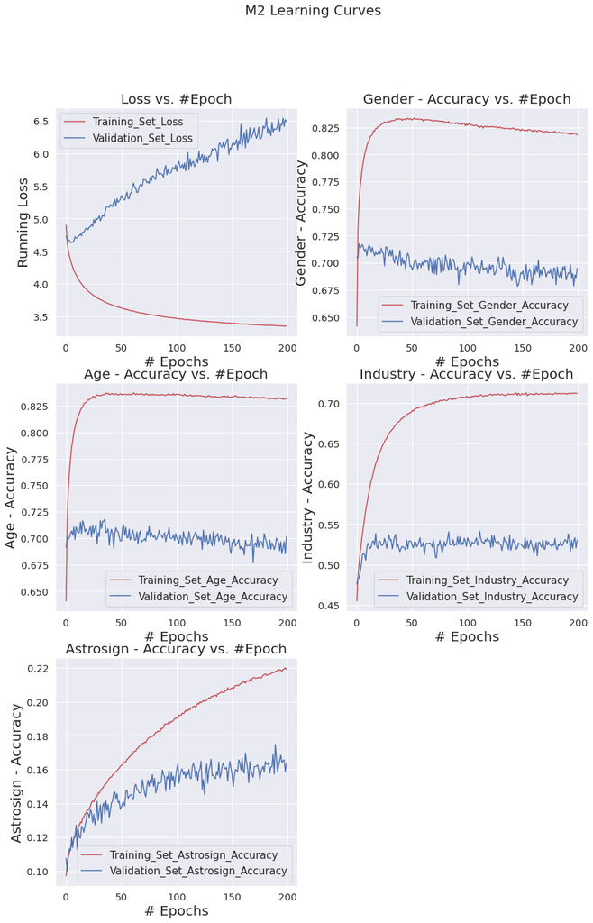

```python
# Load history files from disk
hist_model = np.load(hi_path, allow_pickle = 'TRUE').item()

# Plot training and validation loss
fig = plt.figure(figsize = (14, 21))
fig.suptitle(mod_file_pref + " Learning Curves", fontsize = 20)
ax1 = plt.subplot(3, 2, 1)
ax1.plot(hist_model['loss'], 'r-', label = 'Training_Set_Loss')
ax1.plot(hist_model['val_loss'], 'b-', label = 'Validation_Set_Loss')
ax1.set_title("Loss vs. #Epoch", fontsize = 20)
ax1.set_ylabel('Running Loss', fontsize = 20)
ax1.set_xlabel('# Epochs', fontsize = 20)
ax1.grid(b = True)
ax1.legend(fontsize = 15)

ax2 = plt.subplot(3, 2, 2)
ax2.plot(hist_model['gen_op_binary_accuracy'], 'r-', label = 'Training_Set_Gender_Accuracy')
ax2.plot(hist_model['val_gen_op_binary_accuracy'], 'b-', label = 'Validation_Set_Gender_Accuracy')
ax2.set_title("Gender - Accuracy vs. #Epoch", fontsize = 20)
ax2.set_ylabel('Gender - Accuracy', fontsize = 20)
ax2.set_xlabel('# Epochs', fontsize = 20)
ax2.grid(b = True)
ax2.legend(fontsize = 15)

ax3 = plt.subplot(3, 2, 3)
ax3.plot(hist_model['age_op_categorical_accuracy'], 'r-', label = 'Training_Set_Age_Accuracy')
ax3.plot(hist_model['val_age_op_categorical_accuracy'], 'b-', label = 'Validation_Set_Age_Accuracy')
ax3.set_title("Age - Accuracy vs. #Epoch", fontsize = 20)
ax3.set_ylabel('Age - Accuracy', fontsize = 20)
ax3.set_xlabel('# Epochs', fontsize = 20)
ax3.grid(b = True)
ax3.legend(fontsize = 15)

ax4 = plt.subplot(3, 2, 4)
ax4.plot(hist_model['ind_op_categorical_accuracy'], 'r-', label = 'Training_Set_Industry_Accuracy')
ax4.plot(hist_model['val_ind_op_categorical_accuracy'], 'b-', label = 'Validation_Set_Industry_Accuracy')
ax4.set_title("Industry - Accuracy vs. #Epoch", fontsize = 20)
ax4.set_ylabel('Industry - Accuracy', fontsize = 20)
ax4.set_xlabel('# Epochs', fontsize = 20)
ax4.grid(b = True)
ax4.legend(fontsize = 15)

ax5 = plt.subplot(3, 2, 5)
ax5.plot(hist_model['sgn_op_categorical_accuracy'], 'r-', label = 'Training_Set_Astrosign_Accuracy')
ax5.plot(hist_model['val_sgn_op_categorical_accuracy'], 'b-', label = 'Validation_Set_Astrosign_Accuracy')
ax5.set_title("Astrosign - Accuracy vs. #Epoch", fontsize = 20)
ax5.set_ylabel('Astrosign - Accuracy', fontsize = 20)
ax5.set_xlabel('# Epochs', fontsize = 20)
ax5.grid(b = True)
ax5.legend(fontsize = 15)

# #plt.tight_layout()
plt.show()
```

#### Evaluate accuracy on train and val sets

```python
# Evaluate model on training set
res = model.evaluate(x = train_gen, steps = train_steps_per_epoch, verbose = 0, return_dict = True)
print("Training set gender accuracy is %0.2f %%"\
      %(100 * res['gen_op_gen_op_binary_accuracy']))
print("Training set age accuracy is %0.2f %%"\
      %(100 * res['age_op_age_op_categorical_accuracy']))
print("Training set industry accuracy is %0.2f %%"\
      %(100 * res['ind_op_ind_op_categorical_accuracy']))
print("Training set astrosign accuracy is %0.2f %%"\
      %(100 * res['sgn_op_sgn_op_categorical_accuracy']))
print()

# Evaluate model on validation set
res = model.evaluate(x = val_gen, steps = val_steps_per_epoch, verbose = 0, return_dict = True)
print("Validation set gender accuracy is %0.2f %%"\
      %(100 * res['gen_op_gen_op_binary_accuracy']))
print("Validation set age accuracy is %0.2f %%"\
      %(100 * res['age_op_age_op_categorical_accuracy']))
print("Validation set industry accuracy is %0.2f %%"\
      %(100 * res['ind_op_ind_op_categorical_accuracy']))
print("Validation set astrosign accuracy is %0.2f %%"\
      %(100 * res['sgn_op_sgn_op_categorical_accuracy']))
print()

# Evaluate model on test set
res = model.evaluate(x = test_gen, steps = test_steps_per_epoch, verbose = 0, return_dict = True)
print("Test set gender accuracy is %0.2f %%"\
      %(100 * res['gen_op_gen_op_binary_accuracy']))
print("Test set age accuracy is %0.2f %%"\
      %(100 * res['age_op_age_op_categorical_accuracy']))
print("Test set industry accuracy is %0.2f %%"\
      %(100 * res['ind_op_ind_op_categorical_accuracy']))
print("Test set astrosign accuracy is %0.2f %%"\
      %(100 * res['sgn_op_sgn_op_categorical_accuracy']))
```

```
Training set gender accuracy is 90.13 %
Training set age accuracy is 90.12 %
Training set industry accuracy is 79.56 %
Training set astrosign accuracy is 28.03 %

Validation set gender accuracy is 68.65 %
Validation set age accuracy is 70.35 %
Validation set industry accuracy is 52.70 %
Validation set astrosign accuracy is 16.09 %

Test set gender accuracy is 69.08 %
Test set age accuracy is 69.56 %
Test set industry accuracy is 52.48 %
Test set astrosign accuracy is 15.70 %
```

**This model achieves better accuracy than M1, but the trend is still the same. Test set industry and astrosign accuracies are much lesser than the gender and age accuracies.**

```python
# Delete unnecessary variables to save memory

del X_train, X_train_NN_full, X_val_NN, y_train
```

# Model predictions

We will now make predictions using the above NN based model and look at the results on samples from the training and test sets.

## Training set

```python
## NN model predictions
num_preds = 5 # Number of samples to make predictions on

for ind in range(num_preds):
    samp_ind = np.random.randint(0, X_train_NN.shape[0], 1)[0] # Generate random index
    inp = X_train_NN[samp_ind:(samp_ind + 1)].toarray() # Extract input to feed to model
    act_label = [gen_dict[y_train_gen_NN[samp_ind][0]], age_dict[np.argmax(y_train_age_NN[samp_ind])],\
                 ind_dict[np.argmax(y_train_ind_NN[samp_ind])],\
                 sgn_dict[np.argmax(y_train_sgn_NN[samp_ind])]] # Extract actual label
    pred_label = model.predict(inp) # Get predictions from model
    pred_label = [gen_dict[pred_label[0][0, 0] > 0.5], age_dict[np.argmax(pred_label[1])],\
                  ind_dict[np.argmax(pred_label[2])],\
                  sgn_dict[np.argmax(pred_label[3])]] # Get predicted label
    print("Index in X_train_NN is %d" %(samp_ind))
    print("Actual label is %s" %(act_label))
    print("Predicted label is %s" %(pred_label))
    print()
```

```
Index in X_train_NN is 205558
Actual label is ['female', 'Age_30s', 'Ind_Other', 'Gemini']
Predicted label is ['female', 'Age_30s', 'Ind_Other', 'Gemini']

Index in X_train_NN is 457351
Actual label is ['male', 'Age_20s', 'Ind_Other', 'Leo']
Predicted label is ['male', 'Age_20s', 'Ind_Other', 'Leo']

Index in X_train_NN is 383991
Actual label is ['male', 'Age_10s', 'Student', 'Pisces']
Predicted label is ['male', 'Age_10s', 'Student', 'Libra']

Index in X_train_NN is 75592
Actual label is ['male', 'Age_20s', 'Ind_Other', 'Pisces']
Predicted label is ['male', 'Age_20s', 'Ind_Other', 'Aquarius']

Index in X_train_NN is 88906
Actual label is ['male', 'Age_30s', 'Ind_Other', 'Aries']
Predicted label is ['male', 'Age_30s', 'Ind_Other', 'Aries']
```

## Test set

```python
## NN model predictions
num_preds = 5 # Number of samples to make predictions on

for ind in range(num_preds):
    samp_ind = np.random.randint(0, X_test_NN.shape[0], 1)[0] # Generate random index
    inp = X_test_NN[samp_ind:(samp_ind + 1)].toarray() # Extract input to feed to model
    act_label = [gen_dict[y_test_gen_NN[samp_ind][0]], age_dict[np.argmax(y_test_age_NN[samp_ind])],\
                 ind_dict[np.argmax(y_test_ind_NN[samp_ind])],\
                 sgn_dict[np.argmax(y_test_sgn_NN[samp_ind])]] # Extract actual label
    pred_label = model.predict(inp) # Get predictions from model
    pred_label = [gen_dict[pred_label[0][0, 0] > 0.5], age_dict[np.argmax(pred_label[1])],\
                  ind_dict[np.argmax(pred_label[2])],\
                  sgn_dict[np.argmax(pred_label[3])]] # Get predicted label
    print("Index in X_test_NN is %d" %(samp_ind))
    print("Actual label is %s" %(act_label))
    print("Predicted label is %s" %(pred_label))
    print()
```

```
Index in X_test_NN is 8794
Actual label is ['male', 'Age_20s', 'Student', 'Aquarius']
Predicted label is ['male', 'Age_20s', 'Student', 'Libra']

Index in X_test_NN is 226
Actual label is ['male', 'Age_10s', 'indUnk', 'Aries']
Predicted label is ['female', 'Age_10s', 'indUnk', 'Aries']

Index in X_test_NN is 4050
Actual label is ['male', 'Age_20s', 'indUnk', 'Virgo']
Predicted label is ['female', 'Age_20s', 'Ind_Other', 'Aries']

Index in X_test_NN is 9049
Actual label is ['female', 'Age_10s', 'indUnk', 'Virgo']
Predicted label is ['female', 'Age_10s', 'Student', 'Libra']

Index in X_test_NN is 5320
Actual label is ['male', 'Age_20s', 'Ind_Other', 'Virgo']
Predicted label is ['male', 'Age_20s', 'Ind_Other', 'Leo']
```

**The model gets more incorrect predictions on the test set than the training set since the test set accuracies are worse than the training set.**

**The second part of this notebook (using Glove embeddings) is available in the next notebook: "NLP_Project_I_Part_I_Glove_Suresh_Venkatesan.ipynb"**